# ¿La mejor selección Argentina de la historia?

*Este artículo propone indagar en un método de puntuación que permite analizar selecciones de fútbol a lo largo de la historia: el puntaje Elo. Para ello nos valdremos de R para hacer scraping web, procesamiento de datos y visualizaciones.*

La pregunta que da título a este artículo, obviamente, no tiene una respuesta correcta. Las ponderaciones históricas, y más aún en el ámbito del fútbol, tienen un componente subjetivo importante. Muchas veces, la impronta generacional resulta decisiva: tenemos mayor cariño por equipos que nos deslumbraron en nuestra infancia o juventud y otros que simplemente no pudimos ver en tiempo real o los documentos fílmicos son escasos. Existieron equipos que llegaron más lejos de lo que su juego sugirió, y otros que tuvieron grandes planteles pero que no culminaron con un trofeo.

[figure not shown]

Selección del Mundial 2006

Selecciones que basaron su juego en el funcionamiento colectivo y otros que destacaron por tener una estrella deslumbrante.

[figure not shown]

Selección campeona Mundial 1986

Todas estas variables, y muchas otras, influyen en nuestra elección personal. En esta oportunidad, queremos hacer uso de un sistema que no es el dueño de la verdad, pero puede ser de utilidad para acompañar nuestras percepciones con algún sustento en los datos. Y para practicar R.

## ¿Qué es el sistema Elo?

El nombre proviene de su inventor, Árpád Élő, quien ideó un sistema de puntuación para la clasificación de jugadores de ajedrez, adoptada luego por la Federación Internacional de Ajedrez (FIDE). El método puede ser aplicado para cualquier competencia que enfrente equipos o jugadores entre sí. Consiste en otorgar un puntaje a cada participante relacionado con el rival que enfrenta, y se actualiza en cada partido o comptencia. La [fórmula matemática que lo calcula](https://www.eloratings.net/about) tiene en cuenta la diferencia de puntaje entre ambos competidores. En términos futbolísticos, obtener un triunfo frente a Brasil otorgará un mayor puntaje -o disminuirá menos, en caso de perder- que uno ante Islas Feroe. Además, en el caso del fútbol se agrega una ponderación de acuerdo a la localía -vale más ganar de visitante- y a la competición en que se enmarca el encuentro -vencer en la final de la Copa del Mundo otorga más puntaje que hacerlo en un amistoso-. Actualmente la FIFA utiliza este sistema para sus clasificaciones oficiales [masculina](https://inside.fifa.com/es/fifa-world-ranking/men) y [femenina](https://inside.fifa.com/es/fifa-world-ranking/women).

## Obtención de los datos

Para jugar un poco con los datos vamos a presentar un breve código que extrae los puntajes de todos los países de la página web https://www.international-football.net/elo-ratings-table. Los datos comienzan en 1873, tiempos en los que solo se registran enfrentamientos en el clásico británico Inglaterra-Escocia.[^1]

La idea detrás del código para obtener los datos es hacer una serie de consultas a la página donde se publican los puntajes, de manera que vaya devolviendo los resultados para cada fecha que se elija. Proponemos que se consulte por el primer día de cada mes entre 1873 y la fecha actual. Si bien podría hacerse para todos los días, el tiempo que demoraría sería excesivo, por lo que para ahorrar tiempo -este proceso demora unos 50 minutos- vamos a extraer solo una tabla por mes.

```r
library(rvest) # Paquete para implementar scraping web
library(lubridate) # Paquete para datos con formato fecha
library(tictoc) # Paquete para ver cuánto demoran los procesos

# Fechas que se van a consultar: desde 1873 a 2024, el 1 de cada mes
fechas <- seq.Date(from = as.Date("1873-01-01"),to=Sys.Date(),by="month")


tabla_ratings <- list() # Lista para guardar las tablas según fecha

tic() # Arranca el conteo del tiempo que tomará el proceso

# Consulta: Con un for loop, se recorre la tabla de puntajes para cada fecha
for (i in 1:length(fechas)){
  link <- glue::glue("https://www.international-football.net/elo-ratings-table?year={year(fechas[i])}&month={month(fechas[i])}&day={day(fechas[i])}")
  elo_page <- read_html(link) # Lectura de la parte HTML estática de la web

  # Extracción de los elementos de texto de la web
  summaries_css <- elo_page %>%
    html_elements("td")
  elo_summaries <- html_text(summaries_css)
  # Manipulación de cada tabla para tener un resultado limpio
  rating <- as.data.frame(elo_summaries) %>% # Convierto a data frame
    rename(v1 = elo_summaries) %>% # Cambio de nombre a la variable
    filter(v1 != "") %>% # Saco filas vacías
    slice(-c(1:2)) # Excluyo las primeras 2 filas

# La tabla que devuelve contiene el nombre de país y su puntaje en filas consecutivas
row_odd <- seq_len(nrow(rating)) %% 2  # Selecciono las filas que son impares

  # Armo la tabla: las filas impares son el país y las pares el puntaje. Añado la columna fecha
  tabla_ratings[[i]] <- data.frame(pais = rating[row_odd==1,],elo =  rating[row_odd==0,],
                                   fecha = fechas[i])
  print(fechas[i])

}

toc() # Termina el conteo de tiempo que tomó el proceso


tabla <- do.call(bind_rows, tabla_ratings) # Unifico todas las tablas en 1

# Guardo en formato .rds:
write_rds(tabla,glue::glue("data/elo_ranks_{fechas[1]}_{fechas[length(fechas)]}.rds"))
```

De esta manera tenemos, en una única tabla, los puntajes Elo de las selecciones nacionales entre 1873 y 2024. Veamos cómo está el ranking actualmente

```r
library(tidyverse)

# Lectura de la tabla en formato rds
elo <- read_rds("data/elo_ranks_1873-01-01_2024-04-01.rds") %>%
  mutate(elo = as.numeric(elo), # Convertimos a formato numérico el puntaje
         pais = ifelse(pais == "Falkland Islands","Islas Malvinas",pais)) # Corregimos nombre de las Islas Malvinas

# Mostramos la tabla de forma interactiva, con la función datatable del paquete {DT}
library(DT)
elo %>% filter(fecha == max(fecha)) %>% # Seleccionamos los registros de la última fecha
  arrange(-elo) %>% # Ordenamos valores de forma decreciente
  select(-fecha) %>% # Sacamos la variable fecha
  datatable(caption = glue::glue("Ranking Elo al {format(max(elo$fecha),'%d de %B de %Y')}")) # Tabla y título
```

[output not shown]

## Argentina en el tiempo

Si nos enfocamos en la selección Argentina, podemos seguir su derrotero desde el año 1902. Los picos cuando se obtuvieron las 3 Copas Mundiales son elocuentes. Llama la atención la clasificación durante las décadas de 1940 y 1950, tiempos en los cuales la selección albiceleste tenía grandes participaciones en los Campeonatos Sudamericanos (actual Copa América). En 1957, por ejemplo, [la Argentina obtiene el torneo continental con grandes goleadas (4-0 a Uruguay, 3-0 a Brasil) de la mano de la delantera de *Los Carasucias*](https://es.wikipedia.org/wiki/Campeonato_Sudamericano_1957).

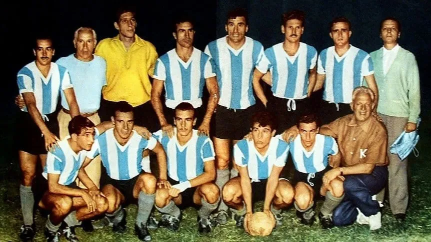

Selección 1957

El puntaje más bajo de la serie corresponde a abril de 1990: el entonces campéon del mundo no hacía pie en la preparación para el mundial de ese año, que culminaría en un subcampeonato.

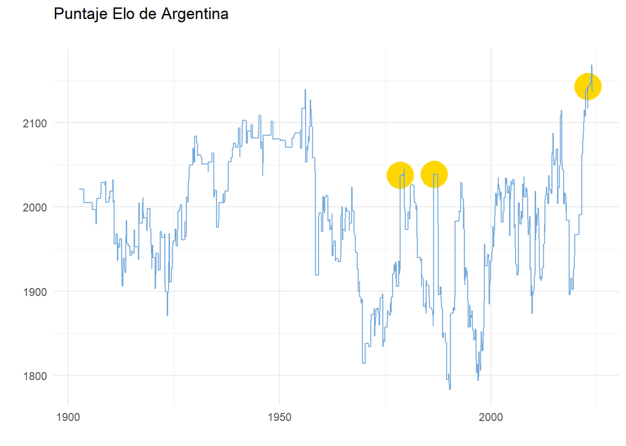

```r
# Graficamos la serie de Argentina
elo %>%
  filter(pais == "Argentina") %>%
  ggplot(aes(x=fecha,y=elo))+
  geom_point(data=elo %>%
    filter(pais == "Argentina" & fecha %in% as.Date(c("1978-08-01","1986-08-01","2023-01-01"))),
  color="gold",size=10)+
  geom_line(color = "#75aadb")+
  theme_minimal()+
  labs(x="",y="",title="Puntaje Elo de Argentina",
       subtitle = "")
```

Los datos del puntaje Elo permiten dar una respuesta a nuestra pregunta incial: el mayor nivel alcanzado por la selección Argentina coincide con la obtención de la última Copa del Mundo. Muchas personas, estimamos, compartirán esta apreciación.

[figure not shown]

Selección campeona Mundial 2022

## Mano a mano

El puntaje Elo nos permite hacer un seguimiento en el tiempo de algunos duelos históricos de selecciones. La memoria reciente de los mundiales no es grata a la hora de recordar los enfrentamientos argentinos con Alemania. En el siglo XXI el país europeo eliminó tres veces seguidas a Argentina (en 2006, 2010 y la final de 2014). A falta de enfrentamientos más recientes podemos hacer uso de las estadísticas que nos provee nuestro amigo Elo. En la actualidad, la diferencia de puntuación a favor de Argentina (esto es el puntaje Elo de Argentina menos el de Alemania) es la mayor desde hace más de 80 años.

```r
# Armamos una tabla con los resultados de Argentina y Alemania

elo_arg_germany <- elo %>% filter(pais %in% c("Argentina","Germany","West Germany")) %>% # Seleccionamos Alemania y Alemania Occidental para tomar la época de la división
  pivot_wider(names_from=pais,values_from=elo) %>% # Pivoteamos la tabla a formato wide
  mutate(Germany = ifelse(is.na(Germany),`West Germany`,Germany)) %>% # Asignamos el valor de Alemania Occidental cuando no hay dato en Alemania
   mutate(dif = Argentina - Germany) %>% # Diferencia de puntajes
  pivot_longer(cols=c("Argentina","Germany","dif"),names_to="var",values_to="val") %>% # Pivoteamos a formato long
  mutate(var_tipo = ifelse(var == "dif","dif","elo"),
         var_tipo = factor(var_tipo,levels = c("elo","dif"),labels=c("elo","dif"))) # Convertimos a formato factor
```

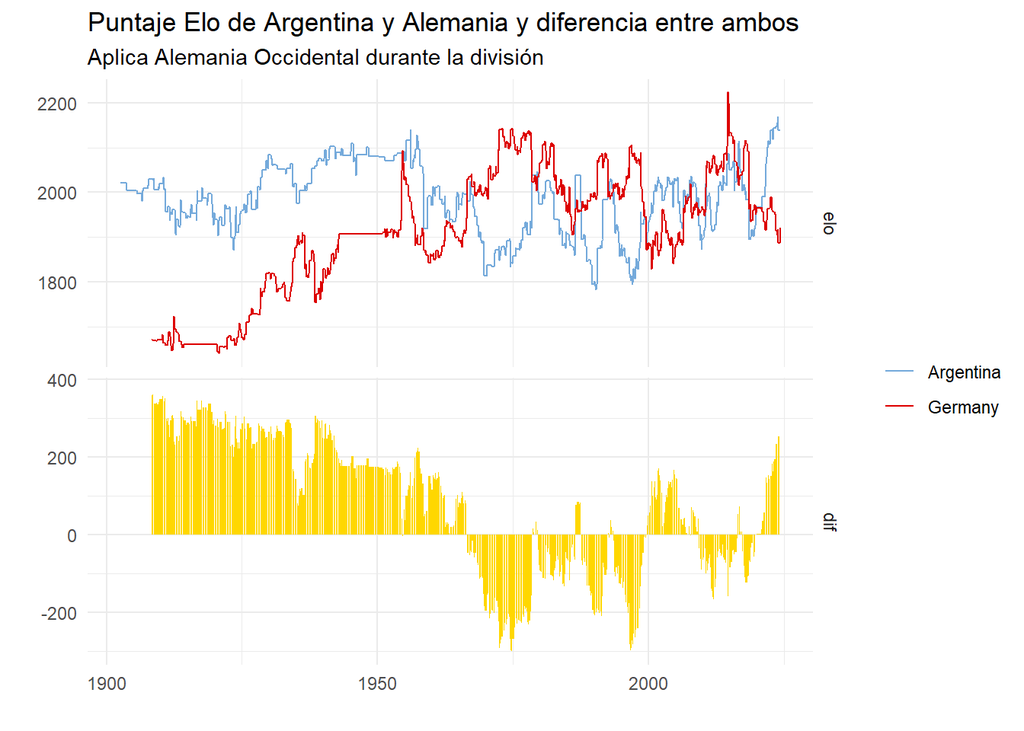

```r
library(ggtext) # Paquete para darle formato al texto

# Graficamos la evolución de las series de Argentina y Alemania, junto con la diferencia
ggplot(elo_arg_germany,aes(x=fecha,y=val)) +
  geom_line(aes(color=var),data=elo_arg_germany %>% filter(var_tipo == "elo"))+ # Líneas de ambas series
  geom_col(data=elo_arg_germany %>% filter(var_tipo == "dif"),fill="gold")+ # Columnas con la diferencia entre ambas
  facet_grid(facets="var_tipo",scales = "free_y")+
  scale_color_manual(values=c("#75aadb","#DD0000"),name="")+
  theme(
    text = element_text(family = "Encode Sans"),
    plot.title =  element_markdown(size = 14, face = "bold"),
    plot.subtitle = element_markdown(size = 12, face = "bold"),
    plot.caption  = element_markdown(size = 10),
    strip.text.y  = element_text(size = 8, face = "bold"),
    axis.text.x   = element_text(size = 6,angle = 90),
    axis.text.y   = element_text(size = 6),
    panel.grid.minor.x = element_blank(),
    panel.grid.major.x = element_blank(),
    legend.position = "none",
    strip.placement = "outside",
    legend.title = element_blank())+
  theme_minimal()+
  labs(x="",y="",title="Puntaje Elo de Argentina y Alemania y diferencia entre ambos",
       subtitle="Aplica Alemania Occidental durante la división")
```

[^1]: Es posible extraer, con un código muy similar, los datos de la web de la FIFA, pero estos inician recién en 1993.